# **Regressão Linear com Erros Normais**

$$\mathbf{Lineu\ Alberto\ Cavazani\ de\ Freitas}$$

$$\mathbf{Prof.\ Cesar\ Augusto\ Taconeli}$$

$$\mathbf{Modelos\ Lineares\ Generalizados\ (CE225)}$$

$$\mathbf{Agosto/2017}$$

# **1. Dados**

Exemplo disponível em: Paula, G. A. (2004). [Modelos de regressão: com apoio computacional](https://www.ime.usp.br/~giapaula/texto_2013.pdf) . São Paulo, SP: IME-USP. (Eg 1.12.5, pág. 94)

Dados referentes ao consumo de combustível em 48 estados norte-americanos.

Variáveis:

1. taxa (taxa do combustível no estado em USD),
2. licença (proporção de motoristas licenciados),
3. renda (renda percapita em USD),
4. estradas (ajuda federal para as estradas em mil USD)
5. consumo (consumo de combustível por habitante).

O objetivo neste estudo é explicar o consumo de combustível pelas variáveis taxa, licença, renda e estradas.

Os dados estão disponíveis no pacote [labestData](https://github.com/pet-estatistica/labestData#instalao-e-uso)

```r
library(labestData)
data(PaulaEg1.12.5)
```

O pacote fornece, além dos dados, sua documentação e um exemplo de análise.Verifique!

Armazenando a base no objeto **dados**:

```r
dados <- PaulaEg1.12.5[ , -1]
```

Primeiras 6 linhas da base:

```r
head(dados)
```

```
##   taxa licen renda  estr cons
## 1    9 0.525  3571  1976  541
## 2    9 0.580  3865  1586  561
## 3    8 0.544  4399   431  410
## 4    8 0.451  5319 11868  344
## 5    8 0.529  4447  8577  464
## 6    8 0.530  4391  5939  580
```

# **2. Análise Descritiva**

Vamos realizar uma breve análise descritiva dos dados.

## 2.1 Medidas Resumo

Usando a função summary verificamos o mínimo, o máximo, a mediana e os quartis para cada variável em estudo.

```r
summary(dados)
```

```
##       taxa            licen            renda           estr
##  Min.   : 5.000   Min.   :0.4510   Min.   :3063   Min.   :  431
##  1st Qu.: 7.000   1st Qu.:0.5298   1st Qu.:3739   1st Qu.: 3110
##  Median : 7.500   Median :0.5645   Median :4298   Median : 4736
##  Mean   : 7.668   Mean   :0.5703   Mean   :4242   Mean   : 5565
##  3rd Qu.: 8.125   3rd Qu.:0.5952   3rd Qu.:4579   3rd Qu.: 7156
##  Max.   :10.000   Max.   :0.7240   Max.   :5342   Max.   :17782
##       cons
##  Min.   :344.0
##  1st Qu.:509.5
##  Median :568.5
##  Mean   :576.8
##  3rd Qu.:632.8
##  Max.   :968.0
```

As medidas descritivas mostram aparente simetria no que diz respeito às variáveis disponíveis. Nota-se também a grande variação da variável resposta consumo, com valores entre 344 e 968.

## 2.2 Boxplot

O boxplot é uma alternativa de análise descritiva para avaliação da distribuição dos dados.

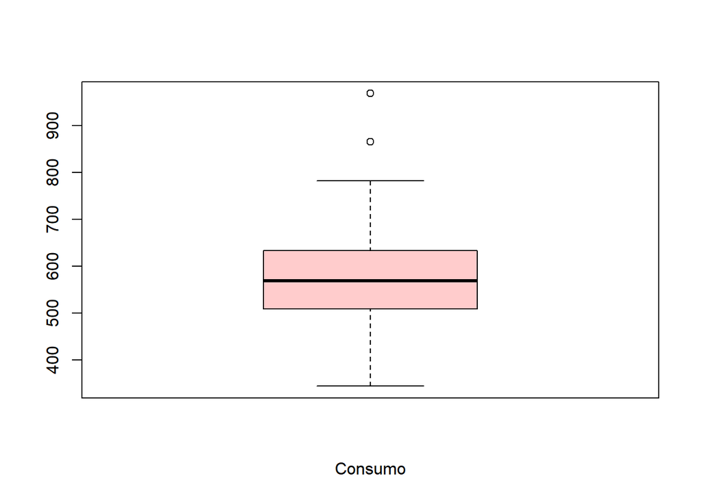

```r
boxplot(dados$cons, xlab = 'Consumo', col = "#FFCCCC")
```

A verificação do boxplot mostra aparente simetria da variável consumo e a presença de alguns valores atípicos.

## 2.3 Gráficos de Dispersão

Os gráficos de dispersão de cada variável explicativa contra a variável resposta permite verificar, preliminarmente, tendências e valores atípicos.

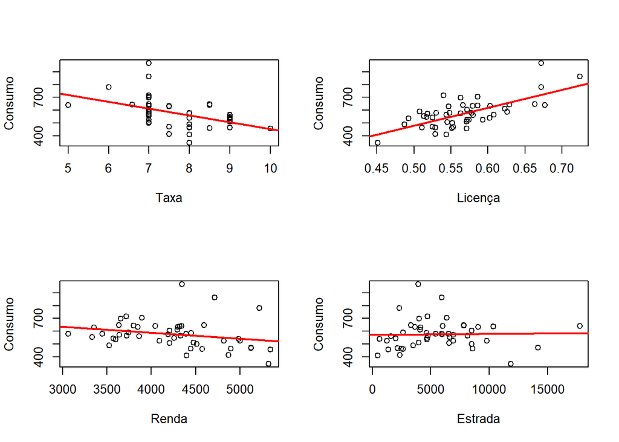

```r
par(mfrow = c(2,2))

plot(cons~taxa, data = dados, xlab = 'Taxa', ylab = 'Consumo')
abline(lm(cons~taxa, data = dados), col=2, lwd = 2)

plot(cons~licen, data = dados, xlab = 'Licença', ylab = 'Consumo')
abline(lm(cons~licen, data = dados), col = 2, lwd = 2)

plot(cons~renda, data = dados, xlab = 'Renda', ylab = 'Consumo')
abline(lm(cons~renda, data = dados), col = 2, lwd = 2)

plot(cons~estr, data = dados, xlab = 'Estrada', ylab = 'Consumo')
abline(lm(cons~estr, data = dados), col = 2, lwd = 2)
```

Visualmente, observando a tendência da variável resposta versus cada variável explicativa, vê-se que a que mais aparenta ter relação com o consumo de combustível por habitante é a proporção de motoristas licenciados.

Adicionalmente é recomendável fazer um estudo da matriz de correlações dos dados. Para isso, foi utilizado o coeficiente de correlação linear de Pearson.

```r
cor <- cor(dados[ ,-1])
cor
```

```
##            licen       renda        estr        cons
## licen  1.0000000  0.15707008 -0.06412950  0.69896542
## renda  0.1570701  1.00000000  0.05016279 -0.24486207
## estr  -0.0641295  0.05016279  1.00000000  0.01904194
## cons   0.6989654 -0.24486207  0.01904194  1.00000000
```

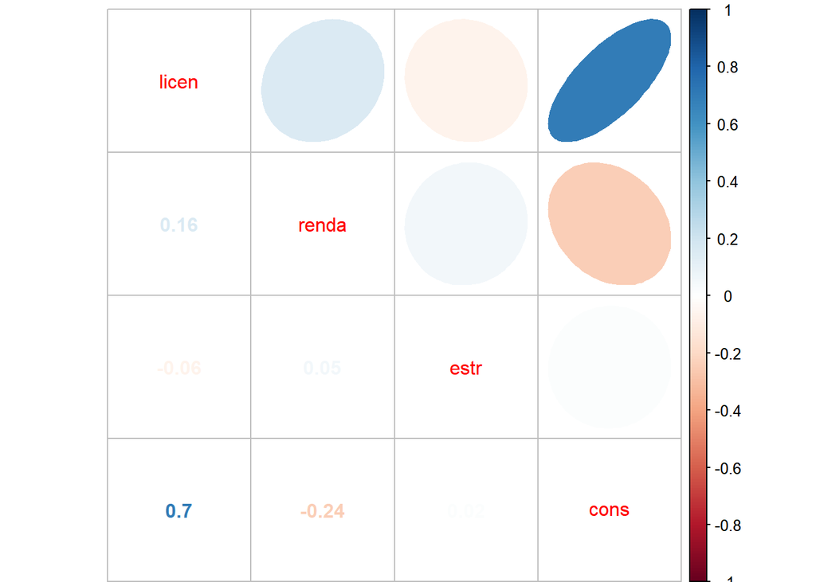

```r
library(corrplot)
corrplot.mixed(cor, upper = "ellipse")
```

Na matriz de correlação evidencia-se a relação entre consumo e proporção de motoristas licenciados. A correlação entre essas duas variáveis é aproximadamente 0,7. Nota-se também a baixa correlação entre consumo e ajuda federal para as estradas.

## 2.4 Histogramas

O histograma é outra alternativa para observar a forma da distribuição dos dados.

- Consumo de Combustível por Habitante (resposta)

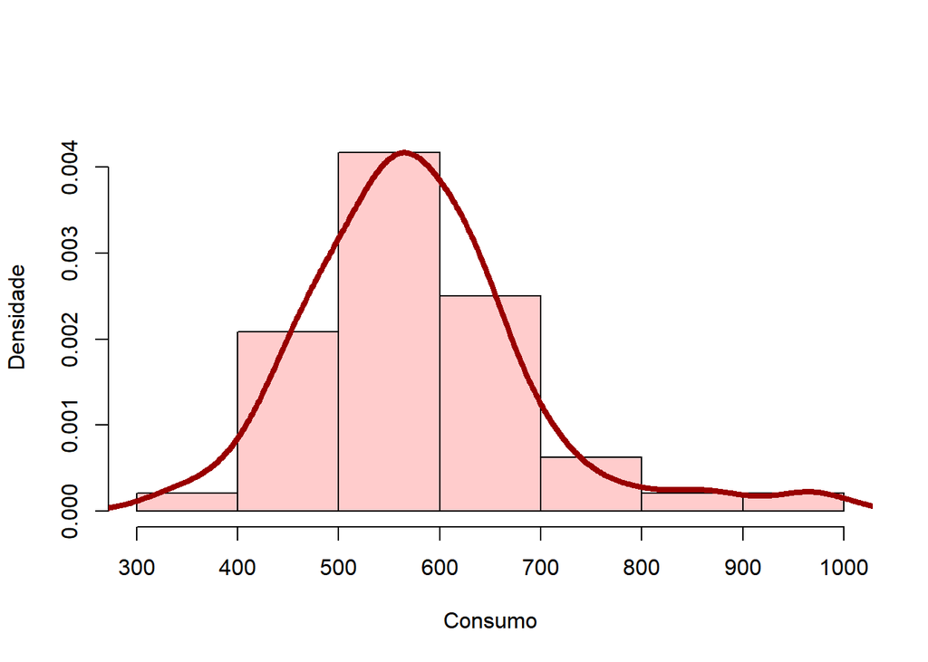

```r
hist(dados$cons, probability = TRUE, xlab = 'Consumo', ylab = 'Densidade',
     main = '', col = "#FFCCCC", ylim = c(0, 0.0045))
lines(density(dados$cons), col = "#990000", lwd = 4)
```

- Variáveis Explicativas

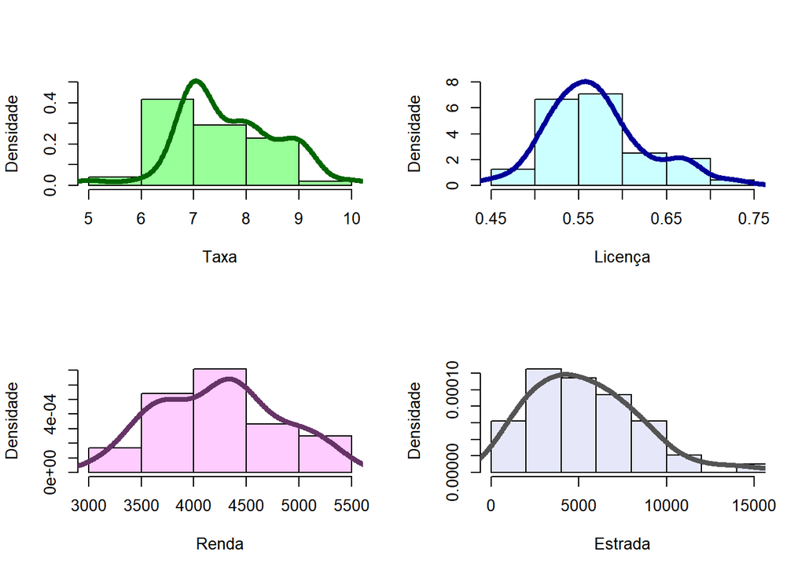

```r
par(mfrow=c(2,2))

hist(dados$taxa, probability = TRUE, xlab = 'Taxa', ylab = 'Densidade',
     main = '', col = "#99FF99", ylim = c(0, 0.5))
lines(density(dados$taxa), col = "#006600", lwd = 4)

hist(dados$licen, probability = TRUE, xlab = 'Licença', ylab = 'Densidade',
     main = '', col = "#CCFFFF", ylim = c(0, 8))
lines(density(dados$licen), col = "#000099", lwd = 4)

hist(dados$renda, probability = TRUE, xlab = 'Renda', ylab = 'Densidade',
     main = '', col = "#FFCCFF")
lines(density(dados$renda), col = "#663366", lwd = 4)

hist(dados$estr, probability = TRUE, xlab = 'Estrada', ylab = 'Densidade',
     main = '', col = "#E6E8FA", xlim = c(0, +15000))
lines(density(dados$estr), col = "#545454", lwd = 4)
```

Marginalmente a variável resposta apresenta distribuição aproximadamente simétrica. Quanto às variáveis explicativas, verifica-se certos desvios de simetria, em especial nas variáveis Taxa e Estrada.

# **3. Ajuste dos Modelos de Regressão**

## 3.1 Ajuste 1

Inicialmente, vamos ajustar o modelo de regressão linear múltipla com todas as variáveis (aditivo) e todas as observações.

A expressão do modelo proposto é dada por:

$$\newcommand{\undertilde}[1]{\underset{\widetilde{}}{#1}}$$

$$y_{i}|\undertilde{x_{i}} \sim Normal(\mu_{i}, \sigma^{2})$$
$$\newcommand{\undertilde}[1]{\underset{\widetilde{}}{#1}}$$
$$\mu_{i} = E(y_{i}|\undertilde{x_{i}}) = {\beta_{0}} + {\beta_{1}}\, taxa_i + {\beta_{2}}\, licen_i + {\beta_{3}}\, renda_i + {\beta_{4}}\, estr_i$$

```r
ajuste1 <- lm(cons ~ taxa + licen + renda + estr, data = dados)
```

### **Análise de Resíduos**

Parte importante da etapa de ajuste de modelos de regressão linear com erros Normais é a análise de resíduos. Nesta fase deve-se verificar os pressupostos do modelo com base na análise dos resíduos: homocedasticidade, Normalidade, independência e identificação de observações discrepantes.

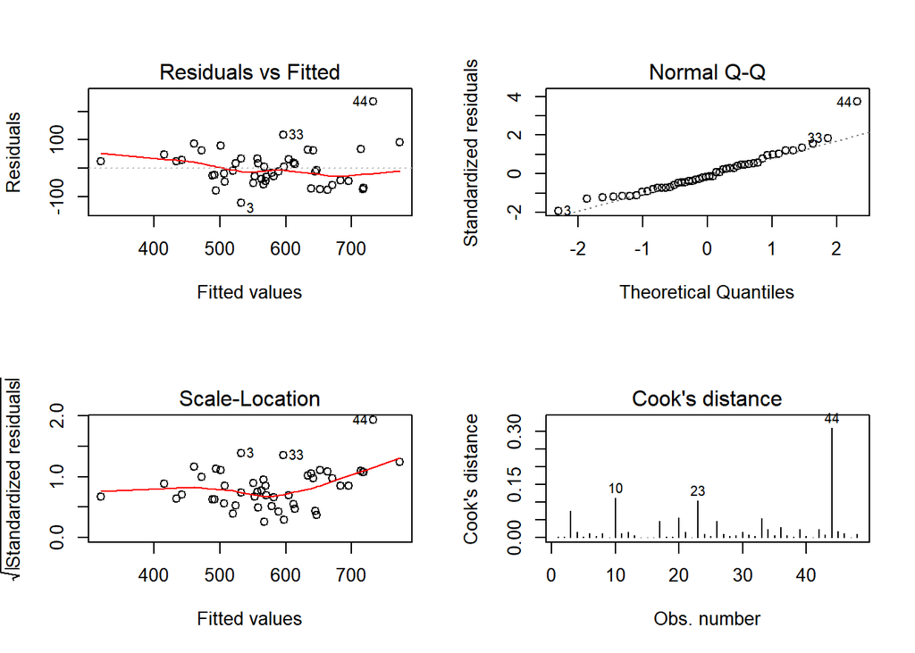

```r
par(mfrow=c(2,2))
plot(ajuste1, which = 1:4)
```

- O gráfico do canto esquerdo superior trás os resíduos ordinários versus os valores ajustados. Esse gráfico é importante para verificação de possíveis padrões não aleatórios, heterocedasticidade, presença de outliers e pontos influentes; o padrão que indica bom ajuste é o de pontos dispersos aleatóriamente e a linha de tendência aproximadamente constante em torno de zero.
- O gráfico do canto direito superior mostra os quantis teóricos da distribuição normal padrão contra os resíduos padronizados. Esse gráfico permite avaliar a pressuposição de normalidade e, caso não haja normalidade, permite avaliar a forma da distribuição, além de indicar possíveis outliers. Pontos dispersos aleatoriamente, nas proximidades da linha identidade (pontilhada), indicam normalidade.
- O gráfico do canto inferior esquerdo apresenta a raiz quadrada dos resíduos padronizados versus os valores ajustados. Esse gráfico é uma alternativa ao primeiro, baseado nos resíduos padronizados. Tendências nesse gráfico são indicativos de variância não constante.
- E por fim, o gráfico do canto inferior direito apresenta os valores da distância de Cook para cada observação. A distância de Cook é uma medida de diferença das estimativas dos parâmetros do modelo ao considerar e ao desconsiderar uma particular observação no ajuste. Observações com valores elevados para essa medida devem ser verificadas.

Os gráficos de resíduos indicam aparente heterocedasticidade, além de observações atípicas.

### **Verificação de Normalidade**

```
## Gaussian model (lm object)
```

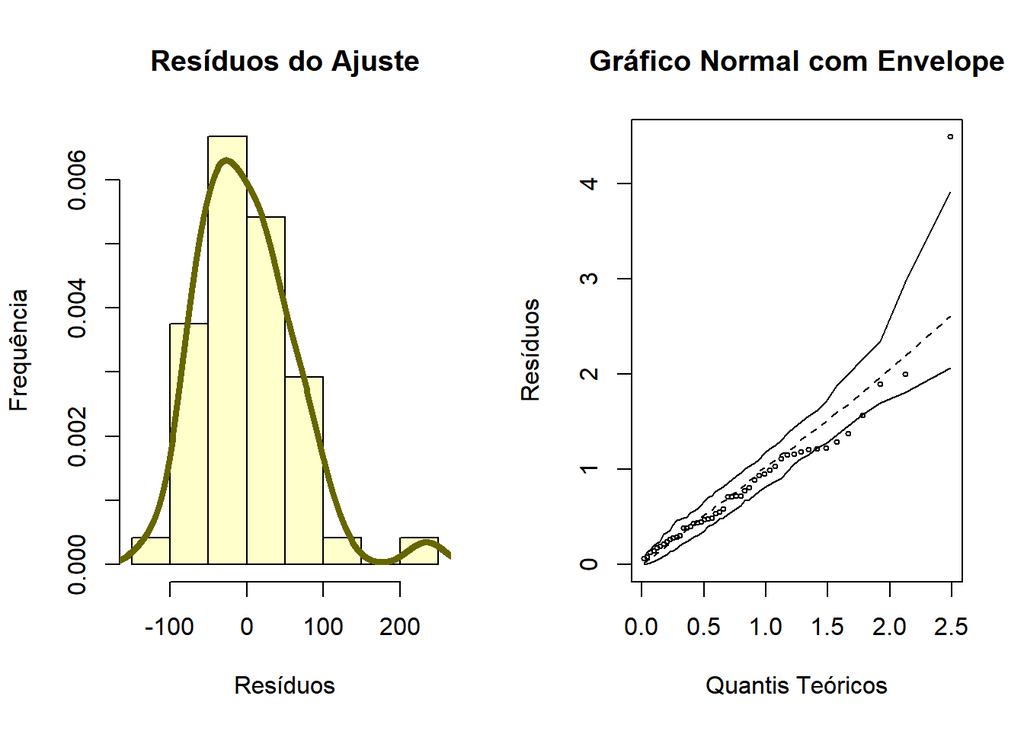

```r
par(mfrow=c(1,2))

hist(ajuste1$residuals, probability = TRUE, main = 'Resíduos do Ajuste',
      xlab = 'Resíduos', ylab = 'Frequência', col = "#FFFFCC") # histograma dos residuos
 lines(density(ajuste1$residuals), col = "#666600", lwd = 4)

 library(hnp)
 hnp(ajuste1, main = 'Gráfico Normal com Envelope', xlab = 'Quantis Teóricos', ylab = 'Resíduos')
```

```r
 shapiro.test(ajuste1$residuals)
```

```
##
##  Shapiro-Wilk normality test
##
## data:  ajuste1$residuals
## W = 0.93918, p-value = 0.0151
```

O teste de de Shapiro-Wilk é um teste utilizado para verificar se a distribuição de probabilidade associada a um conjunto de dados pode ser aproximada pela distribuição normal. As hipóteses do teste são:

$$\begin{matrix}
H_{0} : \textrm{ Os resíduos têm distribuição normal}
\\
H_{1} : \textrm{Os resíduos não têm distribuição normal}
\end{matrix}$$

A análise gráfica apresenta alguns desvios de normalidade. Quanto ao teste de Shapiro-Wilk, ao nível de significância de 5% há evidência suficiente para a rejeição da hipótese nula.

### **Medidas de Infuência**

```r
inf <- influence.measures(ajuste1)
summary(inf)
```

```
## Potentially influential observations of
##   lm(formula = cons ~ taxa + licen + renda + estr, data = dados) :
##
##    dfb.1_ dfb.taxa dfb.licn dfb.rend dfb.estr dffit   cov.r   cook.d
## 4  -0.01   0.04    -0.15     0.16     0.12     0.28    1.53_*  0.02
## 19 -0.02   0.03     0.01     0.01    -0.05    -0.09    1.64_*  0.00
## 27 -0.13   0.14     0.03     0.12     0.01     0.22    1.43_*  0.01
## 30 -0.08   0.08    -0.04     0.12     0.20     0.27    1.42_*  0.01
## 44 -0.35  -0.32     1.02_*  -0.02    -0.38     1.49_*  0.18_*  0.31
##    hat
## 4   0.28
## 19  0.32_*
## 27  0.23
## 30  0.23
## 44  0.10
```

A função influence.measures retorna diferentes medidas de influência e indica potenciais observações influentes no modelo ajustado. São calculados, para cada observação, os valores para DFBETAS, DFFITS, COVRATIO, destância de cook, e os elementos da diagonal da matriz de projeção ortogonal (matriz H).

**DFBETAS**: Medida de influência nas estimativas dos parâmetros do modelo (avaliados um a um);

**DFFITS**: Medida de diferença nos valores ajustados;

**COVRATIO**: Medida de alteração na precisão das estimativas dos parâmetros do modelo;

**COOK**: Medida de diferença no conjunto de estimativas dos parâmetros do modelo;

**HAT**: corresponde à diagonal da matriz de projeção da solução de mínimos quadrados. Tais medidas expressam quão extremas são as observações no espaço das covariáveis.

Com base nos resultados da análise de influência, deve-se:

- Estudar os perfis dos indivíduos 4, 19, 27, 30 e 44.
- Buscar compreender o motivo dos valores discrepantes para as correspondentes medidas;
- Avaliar o efeito dessas observações no ajuste (ajustando um novo modelo sem esses dados e comparando os resultados).

## 3.2 Ajuste 2

Vamos ajustar o modelo de regressão linear múltipla com todas as variáveis e sem as observações 19 e 44, sinalizadas com valores elevados para duas ou mais medidas de influência.

```r
ajuste2 <- lm(cons ~ taxa+licen+renda+estr, data = dados[-c(19, 44), ])
```

Vamos usar a função *compareCoefs*, do pacote *car*, para confrontar os resultados dos dois ajustes:

```r
library(car)
compareCoefs(ajuste1, ajuste2)
```

```
##
## Call:
## 1: lm(formula = cons ~ taxa + licen + renda + estr, data = dados)
## 2: lm(formula = cons ~ taxa + licen + renda + estr, data = dados[-c(19,
##    44), ])
##                Est. 1      SE 1    Est. 2      SE 2
## (Intercept)  3.77e+02  1.86e+02  4.34e+02  1.58e+02
## taxa        -3.48e+01  1.30e+01 -3.17e+01  1.12e+01
## licen        1.34e+03  1.92e+02  1.17e+03  1.66e+02
## renda       -6.66e-02  1.72e-02 -6.64e-02  1.45e-02
## estr        -2.43e-03  3.39e-03 -1.19e-03  3.08e-03
```

Embora algumas estimativas e erros padrões tenham seus valores reduzidos após exclusão das duas observações, não há alterações substanciais quanto às conclusões dos dois modelos (as relações estimativa/erro padrão aproximadamente se mantém, os sinais das estimativas são os mesmos). Vamos avaliar o impacto dessas duas observações na distribuição dos resíduos:

```r
require(hnp)
shapiro.test(ajuste2$residuals)
```

```
##
##  Shapiro-Wilk normality test
##
## data:  ajuste2$residuals
## W = 0.97418, p-value = 0.3923
```

```r
hnp(ajuste2)
```

```
## Gaussian model (lm object)
```

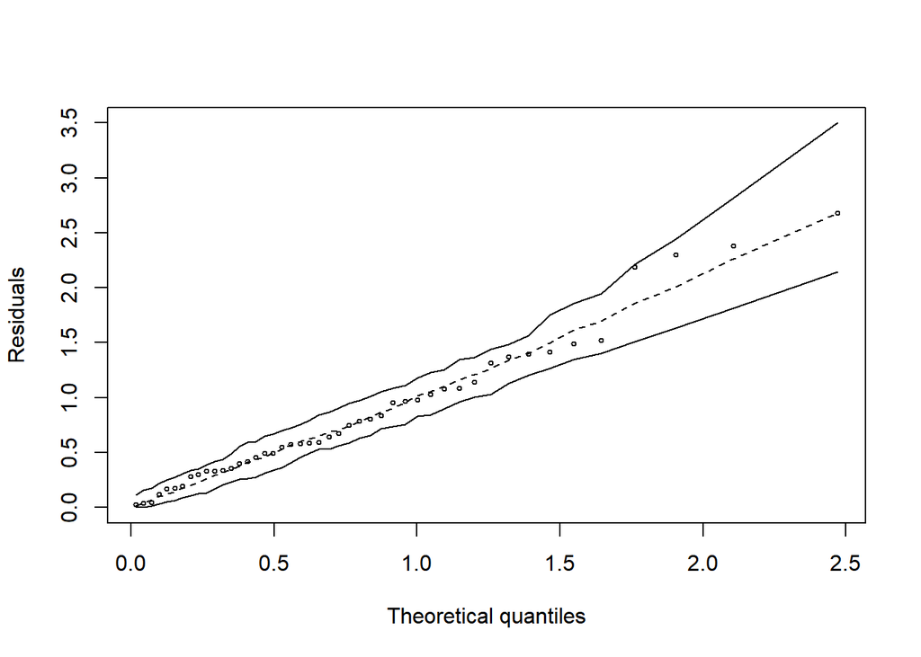

O teste de Shapiro-Wilks e o qq-plot com envelopes simulados indicam agora aderência à distribuição normal. Para a sequência da análise, no entanto, serão consideradas todas as observações, visto que não há alterações inferenciais importantes decorrentes da manutenção desses dois pontos.

Para complementar a análise de resíduos, vamos usar os gráficos de componente + resíduos (função *crPlots* do pacote *car*). Nesse tipo de gráfico tem-se os resíduos versus cada covariável. No entanto, os resíduos são resultantes do ajuste de todas as demais covariáveis (exceto aquela que aparece no eixo horizontal). Permitem avaliar a necessidade e forma de inclusão de cada covariável ao modelo que contém as demais covariáveis.

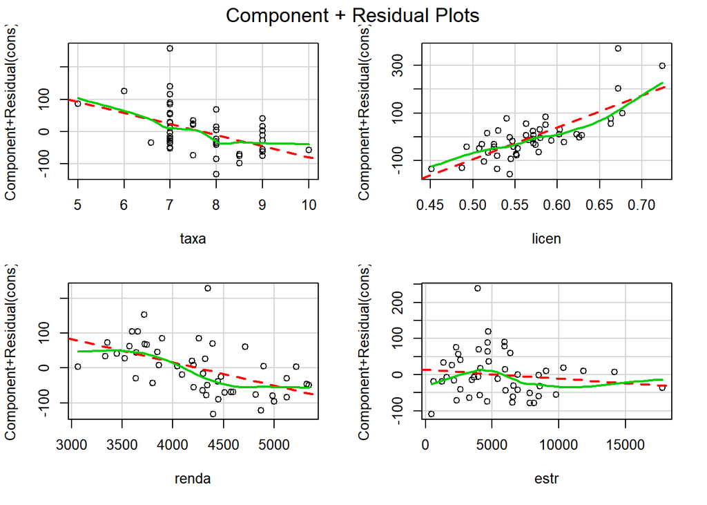

```r
library(car)
crPlots(ajuste1)
```

Pode-se verificar relação decrescente quanto às variáveis *taxa* e *renda* e crescente quanto a *licen*. Com relação à variável *estr*, aparentemente não há relação entre a resposta e essa variável uma vez ajustado o efeito das demais covariáveis.

### **Resumo do Modelo Ajustado**

```r
summary(ajuste1)
```

```
##
## Call:
## lm(formula = cons ~ taxa + licen + renda + estr, data = dados)
##
## Residuals:
##     Min      1Q  Median      3Q     Max
## -122.03  -45.57  -10.66   31.53  234.95
##
## Coefficients:
##               Estimate Std. Error t value Pr(>|t|)
## (Intercept)  3.773e+02  1.855e+02   2.033 0.048207 *
## taxa        -3.479e+01  1.297e+01  -2.682 0.010332 *
## licen        1.336e+03  1.923e+02   6.950 1.52e-08 ***
## renda       -6.659e-02  1.722e-02  -3.867 0.000368 ***
## estr        -2.426e-03  3.389e-03  -0.716 0.477999
## ---
## Signif. codes:  0 '***' 0.001 '**' 0.01 '*' 0.05 '.' 0.1 ' ' 1
##
## Residual standard error: 66.31 on 43 degrees of freedom
## Multiple R-squared:  0.6787, Adjusted R-squared:  0.6488
## F-statistic: 22.71 on 4 and 43 DF,  p-value: 3.907e-10
```

O resumo indica que as variáveis taxa, proporção de motoristas licenciados e renda estão associadas ao consumo, enquanto a variável ajuda federal para as estradas não apresenta relação. Vamos ajustar o modelo linear com erros normais agora sem a ajuda federal.

## 3.3 Ajuste 3

Aqui ajustamos o modelo de regressão linear sem a variável ajuda federal para as estradas.

```r
ajuste3 <- lm(cons ~ taxa + licen + renda, data = dados)
```

### **Análise de Resíduos**

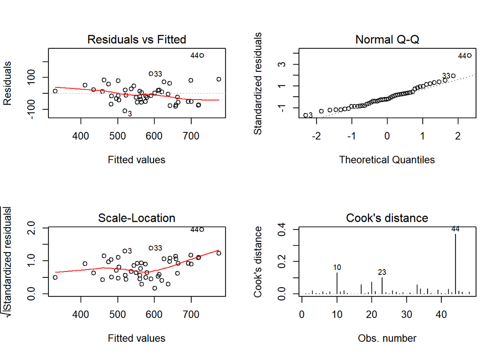

```r
par(mfrow=c(2,2))
plot(ajuste3, which = 1:4)
```

### **Verificação de Normalidade**

```
## Gaussian model (lm object)
```

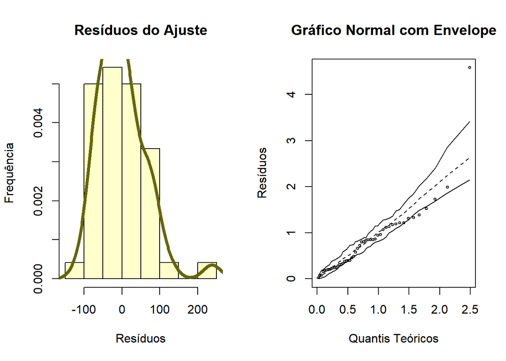

```r
par(mfrow = c(1,2))

hist(ajuste3$residuals, probability = TRUE, main = 'Resíduos do Ajuste',
     xlab = 'Resíduos', ylab = 'Frequência', col = "#FFFFCC") # histograma dos residuos
lines(density(ajuste3$residuals), col = "#666600", lwd = 4)

library(hnp)
 hnp(ajuste3, main = 'Gráfico Normal com Envelope', xlab = 'Quantis Teóricos', ylab = 'Resíduos')
```

```r
shapiro.test(ajuste3$residuals)
```

```
##
##  Shapiro-Wilk normality test
##
## data:  ajuste3$residuals
## W = 0.9282, p-value = 0.005858
```

O resultado do diagnóstico deste ajuste é bastante similar ao verificado para o primeiro modelo. Dessa forma, vamos omitir a etapa de verificação de outliers e observações influentes e seguir para a análise do modelo ajustado.

# **4. Análise do Modelo Ajustado**

As interpretações são baseadas no ajuste do modelo 3, em que foram considerados os dados dos 48 estados e eliminada a variável referente à ajuda federal..

## 4.1 Resumo do Modelo

```r
summary(ajuste3)
```

```
##
## Call:
## lm(formula = cons ~ taxa + licen + renda, data = dados)
##
## Residuals:
##     Min      1Q  Median      3Q     Max
## -110.10  -51.22  -12.89   24.49  238.77
##
## Coefficients:
##               Estimate Std. Error t value Pr(>|t|)
## (Intercept)  307.32790  156.83067   1.960  0.05639 .
## taxa         -29.48381   10.58358  -2.786  0.00785 **
## licen       1374.76841  183.66954   7.485 2.24e-09 ***
## renda         -0.06802    0.01701  -3.999  0.00024 ***
## ---
## Signif. codes:  0 '***' 0.001 '**' 0.01 '*' 0.05 '.' 0.1 ' ' 1
##
## Residual standard error: 65.94 on 44 degrees of freedom
## Multiple R-squared:  0.6749, Adjusted R-squared:  0.6527
## F-statistic: 30.44 on 3 and 44 DF,  p-value: 8.235e-11
```

No summary do modelo podemos verificar o coeficiente de variação (R²) igual a 0.675, o que indica que 67,5% da variação referente à variável resposta é explicada pelas variáveis regressoras usadas no modelo. Adicionalmente, o teste F correspondente à hipótese nula de não significância do modelo ($H_0: \beta_1 = \beta_2 = \beta_3 = 0$) produziu p=8.235e-11, indicando a significância do modelo. Cada uma das variáveis apresentou efeito significativo, ao nível de 5% de significância, ajustado o efeito ads demais covariáveis.

## 4.2 Estimativas

Os valores estimados para os parâmetros do modelo são:

```r
coefficients(ajuste3)
```

```
##   (Intercept)          taxa         licen         renda
##  307.32789650  -29.48380857 1374.76841106   -0.06802286
```

E os interavalos com 95% de confiança para os Parâmetros do Modelo:

```r
confint(ajuste3)
```

```
##                    2.5 %        97.5 %
## (Intercept)   -8.7435503  623.39934333
## taxa         -50.8136042   -8.15401295
## licen       1004.6067761 1744.93004604
## renda         -0.1023038   -0.03374196
```

## 4.3 Modelo Ajustado

A expressão do modelo ajustado fica dada por:

$$E[\widehat{y|x}] = 307,32 - 29,48 \,\, taxa_i + 1374,77 \,\, licen_i - 0.07 \,\, renda_i$$

## 4.3 Interpretação das Estimativas

- Para cada unidade de aumento na variável taxa, estima-se, em média, um decréscimo de aproximadamente 29,49 unidades na variável consumo, mantendo-se fixas as demais variáveis do modelo - IC:(-50,81 ; -8,15);
- Para cada unidade de aumento na variável licen, estima-se, em média, um acréscimo de 1374 unidades na variável consumo, mantendo-se fixas as demais variáveis do modelo - IC:(1004 ; 1745);
- Para cada unidade de aumento na variável renda, estima-se, em média, um decréscimo de 0,07 unidade na variável consumo - IC:(-0,10 ; -0,03).

## 4.5 Gráfico de Efeitos

```r
library(effects)
```

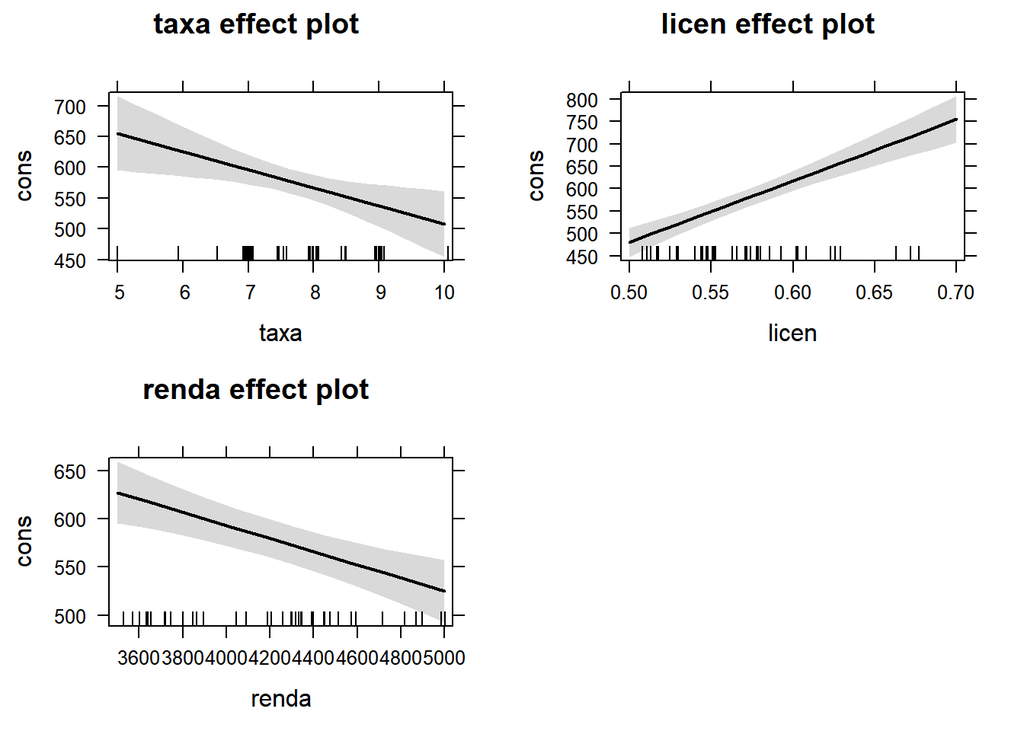

```r
plot(allEffects(ajuste3), type = 'response')
```

A função effects, do pacote de mesmo nome, devolve os efeitos marginais de cada variável um modelo ajustado; os gráficos de efeitos nos fornecem uma forma visual de observar como cada variável explicativa afeta a resposta, com as demais variáveis fixadas na média.

## 4.6 Usando o Modelo Ajustado para Predições

Para fins de ilustração, vamos considerar os seguintes perfis para dois estados distintos:

**Perfil 1:**

1. Taxa do combustível no estado = 7.668333
2. Proporção de motoristas licenciados = 0.5703333
3. Renda percapita no estado = 4241.833

**Perfil 2**

1. Taxa do combustível no estado = 8.483667
2. Proporção de motoristas licenciados = 0.6258036
3. Renda percapita no estado = 4815.457

E responder a seguinte pergunta: *Qual é o consumo médio (ou esperado) de combustível por habitante em estados que tem o Perfil 1 e o Perfil 2?*

```r
perfis <- data.frame(taxa = c(7.668333, 8.483667), licen = c(0.5703333, 0.6258036), renda = c(4241.833, 4815.457))
```

Obtemos assim:

- As estimativas pontuais:

```r
predict(ajuste3, newdata = perfis)
```

```
##        1        2
## 576.7708 589.9709
```

- Intervalos de confiança (95%) para o consumo médio médio.

```r
predict(ajuste3, interval = 'confidence', newdata = perfis)
```

```
##        fit      lwr      upr
## 1 576.7708 557.5900 595.9517
## 2 589.9709 551.0998 628.8421
```

- Intervalos de predição (95%) para a predição.

```r
predict(ajuste3, interval = 'prediction', newdata = perfis)
```

```
##        fit      lwr      upr
## 1 576.7708 442.5050 711.0367
## 2 589.9709 451.5138 728.4281
```

E, finalmente, respondendo a pergunta:

O consumo médio estimado de combustível por habitante de um estado qualquer com o Perfil 1 é igual a 576.77; enquanto para um estado com o Perfil 2 a estimativa é de 589.97.